# Risk Factor Analysis

## Outcome Variable

**Outcome Variable:** whz

## Predictor Variables

**Intervention Variable:** predfeed6

**Adjustment Set:**

- arm
- sex
- month
- brthmon
- W_mage
- meducyrs
- feducyrs
- hhwealth_quart
- hfoodsec
- W_mhtcm
- W_mwtkg
- W_mbmi
- vagbrth
- W_gagebrth
- W_birthwt
- W_birthlen
- W_nrooms
- W_nchldlt5
- W_parity
- impfloor
- impsan
- safeh20
- delta_W_mage
- delta_meducyrs
- delta_feducyrs
- delta_hhwealth_quart
- delta_hfoodsec
- delta_W_mhtcm
- delta_W_mwtkg
- delta_W_mbmi
- delta_vagbrth
- delta_W_gagebrth
- delta_W_birthwt
- delta_W_birthlen
- delta_W_nrooms
- delta_W_nchldlt5
- delta_W_parity
- delta_impfloor
- delta_impsan
- delta_safeh20

## Stratifying Variables

The analysis was stratified on these variable(s):

- agecat
- studyid
- country

## Data Summary

| agecat | studyid | country | predfeed6 | n_cell | n | outcome_variable |
| --- | --- | --- | --- | --- | --- | --- |
| Birth | EE | PAKISTAN | 1 | 24 | 28 | whz |
| Birth | EE | PAKISTAN | 0 | 4 | 28 | whz |
| Birth | GMS-Nepal | NEPAL | 1 | 390 | 522 | whz |
| Birth | GMS-Nepal | NEPAL | 0 | 132 | 522 | whz |
| Birth | JiVitA-3 | BANGLADESH | 1 | 8392 | 10744 | whz |
| Birth | JiVitA-3 | BANGLADESH | 0 | 2352 | 10744 | whz |
| Birth | JiVitA-4 | BANGLADESH | 1 | 1802 | 2224 | whz |
| Birth | JiVitA-4 | BANGLADESH | 0 | 422 | 2224 | whz |
| Birth | MAL-ED | BANGLADESH | 1 | 68 | 194 | whz |
| Birth | MAL-ED | BANGLADESH | 0 | 126 | 194 | whz |
| Birth | MAL-ED | BRAZIL | 1 | 5 | 57 | whz |
| Birth | MAL-ED | BRAZIL | 0 | 52 | 57 | whz |
| Birth | MAL-ED | INDIA | 1 | 4 | 37 | whz |
| Birth | MAL-ED | INDIA | 0 | 33 | 37 | whz |
| Birth | MAL-ED | NEPAL | 1 | 3 | 23 | whz |
| Birth | MAL-ED | NEPAL | 0 | 20 | 23 | whz |
| Birth | MAL-ED | PERU | 1 | 72 | 208 | whz |
| Birth | MAL-ED | PERU | 0 | 136 | 208 | whz |
| Birth | MAL-ED | SOUTH AFRICA | 1 | 1 | 90 | whz |
| Birth | MAL-ED | SOUTH AFRICA | 0 | 89 | 90 | whz |
| Birth | MAL-ED | TANZANIA, UNITED REPUBLIC OF | 1 | 0 | 105 | whz |
| Birth | MAL-ED | TANZANIA, UNITED REPUBLIC OF | 0 | 105 | 105 | whz |
| 6 months | EE | PAKISTAN | 1 | 43 | 48 | whz |
| 6 months | EE | PAKISTAN | 0 | 5 | 48 | whz |
| 6 months | GMS-Nepal | NEPAL | 1 | 406 | 547 | whz |
| 6 months | GMS-Nepal | NEPAL | 0 | 141 | 547 | whz |
| 6 months | JiVitA-3 | BANGLADESH | 1 | 7625 | 9882 | whz |
| 6 months | JiVitA-3 | BANGLADESH | 0 | 2257 | 9882 | whz |
| 6 months | JiVitA-4 | BANGLADESH | 1 | 3327 | 4275 | whz |
| 6 months | JiVitA-4 | BANGLADESH | 0 | 948 | 4275 | whz |
| 6 months | LCNI-5 | MALAWI | 1 | 47 | 272 | whz |
| 6 months | LCNI-5 | MALAWI | 0 | 225 | 272 | whz |
| 6 months | MAL-ED | BANGLADESH | 1 | 84 | 231 | whz |
| 6 months | MAL-ED | BANGLADESH | 0 | 147 | 231 | whz |
| 6 months | MAL-ED | BRAZIL | 1 | 30 | 209 | whz |
| 6 months | MAL-ED | BRAZIL | 0 | 179 | 209 | whz |
| 6 months | MAL-ED | INDIA | 1 | 11 | 218 | whz |
| 6 months | MAL-ED | INDIA | 0 | 207 | 218 | whz |
| 6 months | MAL-ED | NEPAL | 1 | 12 | 225 | whz |
| 6 months | MAL-ED | NEPAL | 0 | 213 | 225 | whz |
| 6 months | MAL-ED | PERU | 1 | 92 | 271 | whz |
| 6 months | MAL-ED | PERU | 0 | 179 | 271 | whz |
| 6 months | MAL-ED | SOUTH AFRICA | 1 | 3 | 233 | whz |
| 6 months | MAL-ED | SOUTH AFRICA | 0 | 230 | 233 | whz |
| 6 months | MAL-ED | TANZANIA, UNITED REPUBLIC OF | 1 | 1 | 232 | whz |
| 6 months | MAL-ED | TANZANIA, UNITED REPUBLIC OF | 0 | 231 | 232 | whz |
| 6 months | SAS-FoodSuppl | INDIA | 1 | 0 | 168 | whz |
| 6 months | SAS-FoodSuppl | INDIA | 0 | 168 | 168 | whz |
| 24 months | EE | PAKISTAN | 1 | 20 | 23 | whz |
| 24 months | EE | PAKISTAN | 0 | 3 | 23 | whz |
| 24 months | GMS-Nepal | NEPAL | 1 | 355 | 469 | whz |
| 24 months | GMS-Nepal | NEPAL | 0 | 114 | 469 | whz |
| 24 months | JiVitA-3 | BANGLADESH | 1 | 3909 | 5067 | whz |
| 24 months | JiVitA-3 | BANGLADESH | 0 | 1158 | 5067 | whz |
| 24 months | JiVitA-4 | BANGLADESH | 1 | 3278 | 4184 | whz |
| 24 months | JiVitA-4 | BANGLADESH | 0 | 906 | 4184 | whz |
| 24 months | LCNI-5 | MALAWI | 1 | 34 | 184 | whz |
| 24 months | LCNI-5 | MALAWI | 0 | 150 | 184 | whz |
| 24 months | MAL-ED | BANGLADESH | 1 | 76 | 205 | whz |
| 24 months | MAL-ED | BANGLADESH | 0 | 129 | 205 | whz |
| 24 months | MAL-ED | BRAZIL | 1 | 25 | 169 | whz |
| 24 months | MAL-ED | BRAZIL | 0 | 144 | 169 | whz |
| 24 months | MAL-ED | INDIA | 1 | 11 | 209 | whz |
| 24 months | MAL-ED | INDIA | 0 | 198 | 209 | whz |
| 24 months | MAL-ED | NEPAL | 1 | 12 | 219 | whz |
| 24 months | MAL-ED | NEPAL | 0 | 207 | 219 | whz |
| 24 months | MAL-ED | PERU | 1 | 68 | 201 | whz |
| 24 months | MAL-ED | PERU | 0 | 133 | 201 | whz |
| 24 months | MAL-ED | SOUTH AFRICA | 1 | 3 | 216 | whz |
| 24 months | MAL-ED | SOUTH AFRICA | 0 | 213 | 216 | whz |
| 24 months | MAL-ED | TANZANIA, UNITED REPUBLIC OF | 1 | 1 | 202 | whz |
| 24 months | MAL-ED | TANZANIA, UNITED REPUBLIC OF | 0 | 201 | 202 | whz |

The following strata were considered:

- agecat: 24 months, studyid: EE, country: PAKISTAN
- agecat: 24 months, studyid: GMS-Nepal, country: NEPAL
- agecat: 24 months, studyid: JiVitA-3, country: BANGLADESH
- agecat: 24 months, studyid: JiVitA-4, country: BANGLADESH
- agecat: 24 months, studyid: LCNI-5, country: MALAWI
- agecat: 24 months, studyid: MAL-ED, country: BANGLADESH
- agecat: 24 months, studyid: MAL-ED, country: BRAZIL
- agecat: 24 months, studyid: MAL-ED, country: INDIA
- agecat: 24 months, studyid: MAL-ED, country: NEPAL
- agecat: 24 months, studyid: MAL-ED, country: PERU
- agecat: 24 months, studyid: MAL-ED, country: SOUTH AFRICA
- agecat: 24 months, studyid: MAL-ED, country: TANZANIA, UNITED REPUBLIC OF
- agecat: 6 months, studyid: EE, country: PAKISTAN
- agecat: 6 months, studyid: GMS-Nepal, country: NEPAL
- agecat: 6 months, studyid: JiVitA-3, country: BANGLADESH
- agecat: 6 months, studyid: JiVitA-4, country: BANGLADESH
- agecat: 6 months, studyid: LCNI-5, country: MALAWI
- agecat: 6 months, studyid: MAL-ED, country: BANGLADESH
- agecat: 6 months, studyid: MAL-ED, country: BRAZIL
- agecat: 6 months, studyid: MAL-ED, country: INDIA
- agecat: 6 months, studyid: MAL-ED, country: NEPAL
- agecat: 6 months, studyid: MAL-ED, country: PERU
- agecat: 6 months, studyid: MAL-ED, country: SOUTH AFRICA
- agecat: 6 months, studyid: MAL-ED, country: TANZANIA, UNITED REPUBLIC OF
- agecat: 6 months, studyid: SAS-FoodSuppl, country: INDIA
- agecat: Birth, studyid: EE, country: PAKISTAN
- agecat: Birth, studyid: GMS-Nepal, country: NEPAL
- agecat: Birth, studyid: JiVitA-3, country: BANGLADESH
- agecat: Birth, studyid: JiVitA-4, country: BANGLADESH
- agecat: Birth, studyid: MAL-ED, country: BANGLADESH
- agecat: Birth, studyid: MAL-ED, country: BRAZIL
- agecat: Birth, studyid: MAL-ED, country: INDIA
- agecat: Birth, studyid: MAL-ED, country: NEPAL
- agecat: Birth, studyid: MAL-ED, country: PERU
- agecat: Birth, studyid: MAL-ED, country: SOUTH AFRICA
- agecat: Birth, studyid: MAL-ED, country: TANZANIA, UNITED REPUBLIC OF

### Dropped Strata

Some strata were dropped due to rare outcomes:

- agecat: Birth, studyid: EE, country: PAKISTAN
- agecat: Birth, studyid: MAL-ED, country: INDIA
- agecat: Birth, studyid: MAL-ED, country: NEPAL
- agecat: Birth, studyid: MAL-ED, country: SOUTH AFRICA
- agecat: Birth, studyid: MAL-ED, country: TANZANIA, UNITED REPUBLIC OF
- agecat: 6 months, studyid: MAL-ED, country: SOUTH AFRICA
- agecat: 6 months, studyid: MAL-ED, country: TANZANIA, UNITED REPUBLIC OF
- agecat: 6 months, studyid: SAS-FoodSuppl, country: INDIA
- agecat: 24 months, studyid: EE, country: PAKISTAN
- agecat: 24 months, studyid: MAL-ED, country: SOUTH AFRICA
- agecat: 24 months, studyid: MAL-ED, country: TANZANIA, UNITED REPUBLIC OF

## Methods Detail

We’re interested in the causal parameters $E[Y_a]$ for all values of $a \in \mathcal{A}$. These parameters represent the mean outcome if, possibly contrary to fact, we intervened to set all units to have $A=a$. Under the randomization and positivity assumptions, these are identified by the statistical parameters $\psi_a=E_W[E_{Y|A,W}(Y|A=a,W)]$. In addition, we’re interested in the mean of $Y$, $E[Y]$ under no intervention (the observed mean). We will estimate these parameters by using SuperLearner to fit the relevant likelihood factors – $E_{Y|A,W}(Y|A=a,W)$ and $p(A=a|W)$, and then updating our likelihood fit using a joint TMLE.

For unadjusted analyses ($W=\{\}$), initial likelihoods were estimated using Lrnr_glm to estimate the simple $E(Y|A)$ and Lrnr_mean to estimate $p(A)$. For adjusted analyses, a small library containing Lrnr_glmnet, Lrnr_xgboost, and Lrnr_mean was used.

Having estimated these parameters, we will then use the delta method to estimate relative risks and attributable risks relative to a prespecified baseline level of $A$.

# Results Detail

## Results Plots

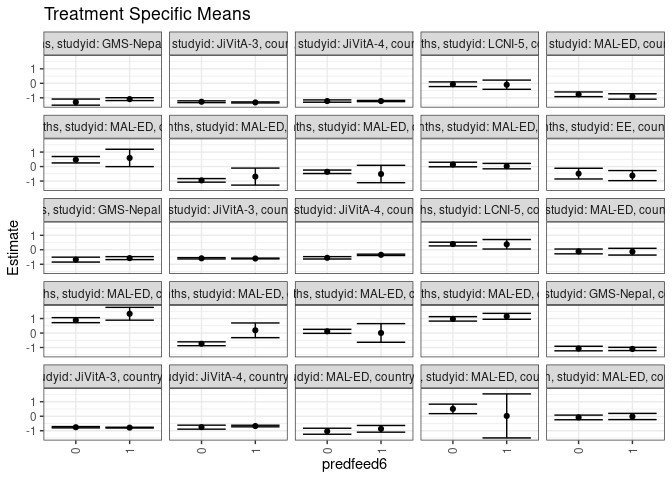

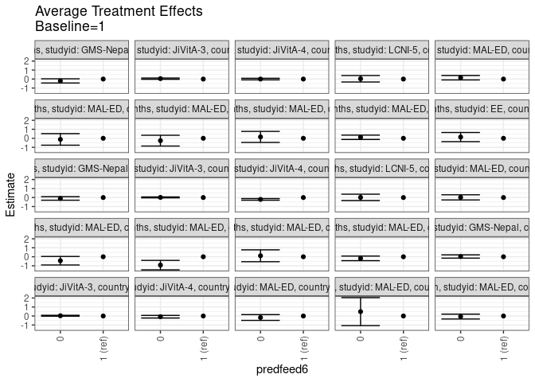

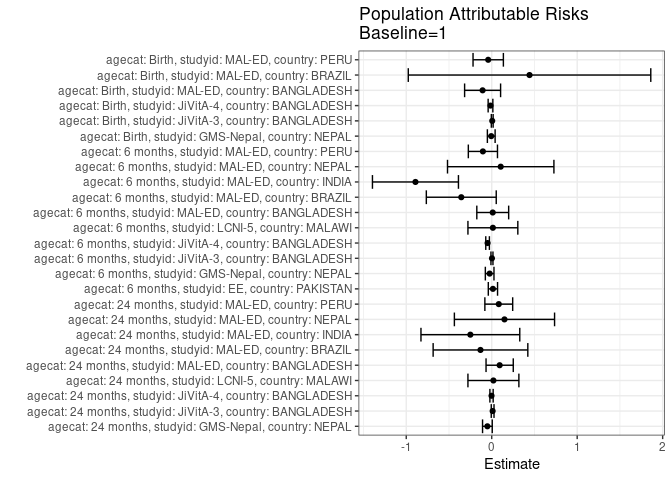

## Results Table

### Parameter: TSM

| agecat | studyid | country | intervention_level | baseline_level | estimate | ci_lower | ci_upper |
| --- | --- | --- | --- | --- | --- | --- | --- |
| Birth | GMS-Nepal | NEPAL | 1 | NA | -1.1009061 | -1.2129349 | -0.9888774 |
| Birth | GMS-Nepal | NEPAL | 0 | NA | -1.0732815 | -1.2308572 | -0.9157058 |
| Birth | JiVitA-3 | BANGLADESH | 1 | NA | -0.7867966 | -0.8115839 | -0.7620092 |
| Birth | JiVitA-3 | BANGLADESH | 0 | NA | -0.7594556 | -0.8031061 | -0.7158051 |
| Birth | JiVitA-4 | BANGLADESH | 1 | NA | -0.6761551 | -0.7311396 | -0.6211706 |
| Birth | JiVitA-4 | BANGLADESH | 0 | NA | -0.7542726 | -0.8931296 | -0.6154156 |
| Birth | MAL-ED | BANGLADESH | 1 | NA | -0.8688889 | -1.1008715 | -0.6369063 |
| Birth | MAL-ED | BANGLADESH | 0 | NA | -1.0359198 | -1.2428888 | -0.8289508 |
| Birth | MAL-ED | BRAZIL | 1 | NA | 0.0220000 | -1.4978207 | 1.5418207 |
| Birth | MAL-ED | BRAZIL | 0 | NA | 0.5069231 | 0.1803892 | 0.8334570 |
| Birth | MAL-ED | PERU | 1 | NA | -0.0177383 | -0.2312898 | 0.1958132 |
| Birth | MAL-ED | PERU | 0 | NA | -0.0816871 | -0.2438311 | 0.0804570 |
| 6 months | EE | PAKISTAN | 1 | NA | -0.6248062 | -0.9715960 | -0.2780164 |
| 6 months | EE | PAKISTAN | 0 | NA | -0.4893333 | -0.8590751 | -0.1195916 |
| 6 months | GMS-Nepal | NEPAL | 1 | NA | -0.5767833 | -0.6789862 | -0.4745804 |
| 6 months | GMS-Nepal | NEPAL | 0 | NA | -0.6786351 | -0.8480851 | -0.5091850 |
| 6 months | JiVitA-3 | BANGLADESH | 1 | NA | -0.6028686 | -0.6299218 | -0.5758154 |
| 6 months | JiVitA-3 | BANGLADESH | 0 | NA | -0.5888533 | -0.6344450 | -0.5432617 |
| 6 months | JiVitA-4 | BANGLADESH | 1 | NA | -0.3484007 | -0.3930216 | -0.3037798 |
| 6 months | JiVitA-4 | BANGLADESH | 0 | NA | -0.5546069 | -0.6371096 | -0.4721042 |
| 6 months | LCNI-5 | MALAWI | 1 | NA | 0.3789154 | 0.0505173 | 0.7073135 |
| 6 months | LCNI-5 | MALAWI | 0 | NA | 0.3960472 | 0.2692086 | 0.5228857 |
| 6 months | MAL-ED | BANGLADESH | 1 | NA | -0.1332545 | -0.3658867 | 0.0993776 |
| 6 months | MAL-ED | BANGLADESH | 0 | NA | -0.1145366 | -0.2801156 | 0.0510424 |
| 6 months | MAL-ED | BRAZIL | 1 | NA | 1.3281850 | 0.8855387 | 1.7708314 |
| 6 months | MAL-ED | BRAZIL | 0 | NA | 0.8889256 | 0.7143315 | 1.0635196 |
| 6 months | MAL-ED | INDIA | 1 | NA | 0.1856285 | -0.3210052 | 0.6922622 |
| 6 months | MAL-ED | INDIA | 0 | NA | -0.7421500 | -0.8756481 | -0.6086519 |
| 6 months | MAL-ED | NEPAL | 1 | NA | 0.0039859 | -0.6389389 | 0.6469107 |
| 6 months | MAL-ED | NEPAL | 0 | NA | 0.1151664 | -0.0238953 | 0.2542281 |
| 6 months | MAL-ED | PERU | 1 | NA | 1.1537688 | 0.9499227 | 1.3576150 |
| 6 months | MAL-ED | PERU | 0 | NA | 0.9755708 | 0.8225578 | 1.1285837 |
| 24 months | GMS-Nepal | NEPAL | 1 | NA | -1.0918058 | -1.1913910 | -0.9922205 |
| 24 months | GMS-Nepal | NEPAL | 0 | NA | -1.2986678 | -1.5090675 | -1.0882681 |
| 24 months | JiVitA-3 | BANGLADESH | 1 | NA | -1.3210590 | -1.3557647 | -1.2863534 |
| 24 months | JiVitA-3 | BANGLADESH | 0 | NA | -1.2735767 | -1.3355372 | -1.2116162 |
| 24 months | JiVitA-4 | BANGLADESH | 1 | NA | -1.2243349 | -1.2649993 | -1.1836705 |
| 24 months | JiVitA-4 | BANGLADESH | 0 | NA | -1.2245296 | -1.3043503 | -1.1447090 |
| 24 months | LCNI-5 | MALAWI | 1 | NA | -0.0968039 | -0.4148405 | 0.2212327 |
| 24 months | LCNI-5 | MALAWI | 0 | NA | -0.0631435 | -0.2244322 | 0.0981451 |
| 24 months | MAL-ED | BANGLADESH | 1 | NA | -0.9098234 | -1.0959584 | -0.7236884 |
| 24 months | MAL-ED | BANGLADESH | 0 | NA | -0.7602873 | -0.9216562 | -0.5989184 |
| 24 months | MAL-ED | BRAZIL | 1 | NA | 0.5941284 | -0.0057525 | 1.1940092 |
| 24 months | MAL-ED | BRAZIL | 0 | NA | 0.4700401 | 0.2489018 | 0.6911784 |
| 24 months | MAL-ED | INDIA | 1 | NA | -0.6944351 | -1.2811308 | -0.1077395 |
| 24 months | MAL-ED | INDIA | 0 | NA | -0.9560713 | -1.0800104 | -0.8321322 |
| 24 months | MAL-ED | NEPAL | 1 | NA | -0.5166627 | -1.1167435 | 0.0834181 |
| 24 months | MAL-ED | NEPAL | 0 | NA | -0.3631953 | -0.4830447 | -0.2433459 |
| 24 months | MAL-ED | PERU | 1 | NA | 0.0286932 | -0.1593676 | 0.2167540 |
| 24 months | MAL-ED | PERU | 0 | NA | 0.1407875 | -0.0171529 | 0.2987279 |

### Parameter: E(Y)

| agecat | studyid | country | intervention_level | baseline_level | estimate | ci_lower | ci_upper |
| --- | --- | --- | --- | --- | --- | --- | --- |
| Birth | GMS-Nepal | NEPAL | NA | NA | -1.1064559 | -1.2034951 | -1.0094168 |
| Birth | JiVitA-3 | BANGLADESH | NA | NA | -0.7807809 | -0.8030521 | -0.7585097 |
| Birth | JiVitA-4 | BANGLADESH | NA | NA | -0.6904586 | -0.7435822 | -0.6373351 |
| Birth | MAL-ED | BANGLADESH | NA | NA | -0.9755670 | -1.1287016 | -0.8224325 |
| Birth | MAL-ED | BRAZIL | NA | NA | 0.4643860 | 0.1360519 | 0.7927200 |
| Birth | MAL-ED | PERU | NA | NA | -0.0587981 | -0.1871869 | 0.0695908 |
| 6 months | EE | PAKISTAN | NA | NA | -0.6106944 | -0.9239621 | -0.2974268 |
| 6 months | GMS-Nepal | NEPAL | NA | NA | -0.6009171 | -0.6886356 | -0.5131986 |
| 6 months | JiVitA-3 | BANGLADESH | NA | NA | -0.6001300 | -0.6240378 | -0.5762223 |
| 6 months | JiVitA-4 | BANGLADESH | NA | NA | -0.3968456 | -0.4358721 | -0.3578192 |
| 6 months | LCNI-5 | MALAWI | NA | NA | 0.3925000 | 0.2735307 | 0.5114693 |
| 6 months | MAL-ED | BANGLADESH | NA | NA | -0.1213203 | -0.2539388 | 0.0112981 |
| 6 months | MAL-ED | BRAZIL | NA | NA | 0.9720774 | 0.8078144 | 1.1363403 |
| 6 months | MAL-ED | INDIA | NA | NA | -0.7067317 | -0.8369134 | -0.5765499 |
| 6 months | MAL-ED | NEPAL | NA | NA | 0.1091407 | -0.0265536 | 0.2448351 |
| 6 months | MAL-ED | PERU | NA | NA | 1.0506150 | 0.9281868 | 1.1730433 |
| 24 months | GMS-Nepal | NEPAL | NA | NA | -1.1423525 | -1.2336321 | -1.0510729 |
| 24 months | JiVitA-3 | BANGLADESH | NA | NA | -1.3103375 | -1.3408810 | -1.2797940 |
| 24 months | JiVitA-4 | BANGLADESH | NA | NA | -1.2265320 | -1.2620508 | -1.1910132 |
| 24 months | LCNI-5 | MALAWI | NA | NA | -0.0770652 | -0.2204213 | 0.0662909 |
| 24 months | MAL-ED | BANGLADESH | NA | NA | -0.8169756 | -0.9388013 | -0.6951499 |
| 24 months | MAL-ED | BRAZIL | NA | NA | 0.4626233 | 0.2567495 | 0.6684971 |
| 24 months | MAL-ED | INDIA | NA | NA | -0.9442584 | -1.0642426 | -0.8242742 |
| 24 months | MAL-ED | NEPAL | NA | NA | -0.3674429 | -0.4840752 | -0.2508107 |
| 24 months | MAL-ED | PERU | NA | NA | 0.1111982 | -0.0118399 | 0.2342362 |

### Parameter: ATE

| agecat | studyid | country | intervention_level | baseline_level | estimate | ci_lower | ci_upper |
| --- | --- | --- | --- | --- | --- | --- | --- |
| Birth | GMS-Nepal | NEPAL | 1 | 1 | 0.0000000 | 0.0000000 | 0.0000000 |
| Birth | GMS-Nepal | NEPAL | 0 | 1 | 0.0276246 | -0.1538245 | 0.2090737 |
| Birth | JiVitA-3 | BANGLADESH | 1 | 1 | 0.0000000 | 0.0000000 | 0.0000000 |
| Birth | JiVitA-3 | BANGLADESH | 0 | 1 | 0.0273410 | -0.0210239 | 0.0757058 |
| Birth | JiVitA-4 | BANGLADESH | 1 | 1 | 0.0000000 | 0.0000000 | 0.0000000 |
| Birth | JiVitA-4 | BANGLADESH | 0 | 1 | -0.0781175 | -0.2238802 | 0.0676452 |
| Birth | MAL-ED | BANGLADESH | 1 | 1 | 0.0000000 | 0.0000000 | 0.0000000 |
| Birth | MAL-ED | BANGLADESH | 0 | 1 | -0.1670309 | -0.4866213 | 0.1525595 |
| Birth | MAL-ED | BRAZIL | 1 | 1 | 0.0000000 | 0.0000000 | 0.0000000 |
| Birth | MAL-ED | BRAZIL | 0 | 1 | 0.4849231 | -1.0695798 | 2.0394260 |
| Birth | MAL-ED | PERU | 1 | 1 | 0.0000000 | 0.0000000 | 0.0000000 |
| Birth | MAL-ED | PERU | 0 | 1 | -0.0639488 | -0.3331600 | 0.2052624 |
| 6 months | EE | PAKISTAN | 1 | 1 | 0.0000000 | 0.0000000 | 0.0000000 |
| 6 months | EE | PAKISTAN | 0 | 1 | 0.1354729 | -0.3714513 | 0.6423970 |
| 6 months | GMS-Nepal | NEPAL | 1 | 1 | 0.0000000 | 0.0000000 | 0.0000000 |
| 6 months | GMS-Nepal | NEPAL | 0 | 1 | -0.1018518 | -0.2986453 | 0.0949418 |
| 6 months | JiVitA-3 | BANGLADESH | 1 | 1 | 0.0000000 | 0.0000000 | 0.0000000 |
| 6 months | JiVitA-3 | BANGLADESH | 0 | 1 | 0.0140153 | -0.0376055 | 0.0656361 |
| 6 months | JiVitA-4 | BANGLADESH | 1 | 1 | 0.0000000 | 0.0000000 | 0.0000000 |
| 6 months | JiVitA-4 | BANGLADESH | 0 | 1 | -0.2062062 | -0.2992755 | -0.1131370 |
| 6 months | LCNI-5 | MALAWI | 1 | 1 | 0.0000000 | 0.0000000 | 0.0000000 |
| 6 months | LCNI-5 | MALAWI | 0 | 1 | 0.0171318 | -0.3350303 | 0.3692938 |
| 6 months | MAL-ED | BANGLADESH | 1 | 1 | 0.0000000 | 0.0000000 | 0.0000000 |
| 6 months | MAL-ED | BANGLADESH | 0 | 1 | 0.0187179 | -0.2683823 | 0.3058181 |
| 6 months | MAL-ED | BRAZIL | 1 | 1 | 0.0000000 | 0.0000000 | 0.0000000 |
| 6 months | MAL-ED | BRAZIL | 0 | 1 | -0.4392595 | -0.9156922 | 0.0371732 |
| 6 months | MAL-ED | INDIA | 1 | 1 | 0.0000000 | 0.0000000 | 0.0000000 |
| 6 months | MAL-ED | INDIA | 0 | 1 | -0.9277785 | -1.4528818 | -0.4026753 |
| 6 months | MAL-ED | NEPAL | 1 | 1 | 0.0000000 | 0.0000000 | 0.0000000 |
| 6 months | MAL-ED | NEPAL | 0 | 1 | 0.1111805 | -0.5467515 | 0.7691125 |
| 6 months | MAL-ED | PERU | 1 | 1 | 0.0000000 | 0.0000000 | 0.0000000 |
| 6 months | MAL-ED | PERU | 0 | 1 | -0.1781981 | -0.4339790 | 0.0775829 |
| 24 months | GMS-Nepal | NEPAL | 1 | 1 | 0.0000000 | 0.0000000 | 0.0000000 |
| 24 months | GMS-Nepal | NEPAL | 0 | 1 | -0.2068620 | -0.4398389 | 0.0261150 |
| 24 months | JiVitA-3 | BANGLADESH | 1 | 1 | 0.0000000 | 0.0000000 | 0.0000000 |
| 24 months | JiVitA-3 | BANGLADESH | 0 | 1 | 0.0474823 | -0.0227888 | 0.1177535 |
| 24 months | JiVitA-4 | BANGLADESH | 1 | 1 | 0.0000000 | 0.0000000 | 0.0000000 |
| 24 months | JiVitA-4 | BANGLADESH | 0 | 1 | -0.0001947 | -0.0877977 | 0.0874082 |
| 24 months | LCNI-5 | MALAWI | 1 | 1 | 0.0000000 | 0.0000000 | 0.0000000 |
| 24 months | LCNI-5 | MALAWI | 0 | 1 | 0.0336604 | -0.3249290 | 0.3922498 |
| 24 months | MAL-ED | BANGLADESH | 1 | 1 | 0.0000000 | 0.0000000 | 0.0000000 |
| 24 months | MAL-ED | BANGLADESH | 0 | 1 | 0.1495361 | -0.0974907 | 0.3965629 |
| 24 months | MAL-ED | BRAZIL | 1 | 1 | 0.0000000 | 0.0000000 | 0.0000000 |
| 24 months | MAL-ED | BRAZIL | 0 | 1 | -0.1240883 | -0.7647145 | 0.5165380 |
| 24 months | MAL-ED | INDIA | 1 | 1 | 0.0000000 | 0.0000000 | 0.0000000 |
| 24 months | MAL-ED | INDIA | 0 | 1 | -0.2616361 | -0.8615333 | 0.3382610 |
| 24 months | MAL-ED | NEPAL | 1 | 1 | 0.0000000 | 0.0000000 | 0.0000000 |
| 24 months | MAL-ED | NEPAL | 0 | 1 | 0.1534674 | -0.4585631 | 0.7654979 |
| 24 months | MAL-ED | PERU | 1 | 1 | 0.0000000 | 0.0000000 | 0.0000000 |
| 24 months | MAL-ED | PERU | 0 | 1 | 0.1120943 | -0.1316775 | 0.3558661 |

### Parameter: PAR

| agecat | studyid | country | intervention_level | baseline_level | estimate | ci_lower | ci_upper |
| --- | --- | --- | --- | --- | --- | --- | --- |
| Birth | GMS-Nepal | NEPAL | 1 | NA | -0.0055498 | -0.0508507 | 0.0397511 |
| Birth | JiVitA-3 | BANGLADESH | 1 | NA | 0.0060157 | -0.0045470 | 0.0165783 |
| Birth | JiVitA-4 | BANGLADESH | 1 | NA | -0.0143035 | -0.0418289 | 0.0132219 |
| Birth | MAL-ED | BANGLADESH | 1 | NA | -0.1066781 | -0.3172016 | 0.1038454 |
| Birth | MAL-ED | BRAZIL | 1 | NA | 0.4423860 | -0.9762121 | 1.8609840 |
| Birth | MAL-ED | PERU | 1 | NA | -0.0410598 | -0.2185578 | 0.1364382 |
| 6 months | EE | PAKISTAN | 1 | NA | 0.0141118 | -0.0400020 | 0.0682256 |
| 6 months | GMS-Nepal | NEPAL | 1 | NA | -0.0241338 | -0.0746249 | 0.0263572 |
| 6 months | JiVitA-3 | BANGLADESH | 1 | NA | 0.0027386 | -0.0090713 | 0.0145484 |
| 6 months | JiVitA-4 | BANGLADESH | 1 | NA | -0.0484449 | -0.0696948 | -0.0271951 |
| 6 months | LCNI-5 | MALAWI | 1 | NA | 0.0135846 | -0.2782461 | 0.3054152 |
| 6 months | MAL-ED | BANGLADESH | 1 | NA | 0.0119342 | -0.1743959 | 0.1982643 |
| 6 months | MAL-ED | BRAZIL | 1 | NA | -0.3561077 | -0.7650977 | 0.0528823 |
| 6 months | MAL-ED | INDIA | 1 | NA | -0.8923602 | -1.3954306 | -0.3892898 |
| 6 months | MAL-ED | NEPAL | 1 | NA | 0.1051549 | -0.5173098 | 0.7276196 |
| 6 months | MAL-ED | PERU | 1 | NA | -0.1031538 | -0.2736539 | 0.0673462 |
| 24 months | GMS-Nepal | NEPAL | 1 | NA | -0.0505467 | -0.1072496 | 0.0061561 |
| 24 months | JiVitA-3 | BANGLADESH | 1 | NA | 0.0107216 | -0.0053947 | 0.0268378 |
| 24 months | JiVitA-4 | BANGLADESH | 1 | NA | -0.0021971 | -0.0213103 | 0.0169161 |
| 24 months | LCNI-5 | MALAWI | 1 | NA | 0.0197387 | -0.2782917 | 0.3177691 |
| 24 months | MAL-ED | BANGLADESH | 1 | NA | 0.0928478 | -0.0664132 | 0.2521089 |
| 24 months | MAL-ED | BRAZIL | 1 | NA | -0.1315051 | -0.6854118 | 0.4224017 |
| 24 months | MAL-ED | INDIA | 1 | NA | -0.2498232 | -0.8278041 | 0.3281577 |
| 24 months | MAL-ED | NEPAL | 1 | NA | 0.1492198 | -0.4368699 | 0.7353095 |
| 24 months | MAL-ED | PERU | 1 | NA | 0.0825049 | -0.0802230 | 0.2452329 |